# Reproducible Research: Peer Assessment 1

## Loading and preprocessing the data

1. Load the data

```r
readfile <- read.csv("activity.csv", na.strings="NA")
```

Review the data file

```r
head(readfile,5)
```

```
##   steps       date interval
## 1    NA 2012-10-01        0
## 2    NA 2012-10-01        5
## 3    NA 2012-10-01       10
## 4    NA 2012-10-01       15
## 5    NA 2012-10-01       20
```

```r
str(readfile)
```

```
## 'data.frame':    17568 obs. of  3 variables:
##  $ steps   : int  NA NA NA NA NA NA NA NA NA NA ...
##  $ date    : Factor w/ 61 levels "2012-10-01","2012-10-02",..: 1 1 1 1 1 1 1 1 1 1 ...
##  $ interval: int  0 5 10 15 20 25 30 35 40 45 ...
```

2. Remove “NA” values

```r
rd2 <- na.omit(readfile)
```

## What is mean total number of steps taken per day?

1. Sum the total number of steps taken per day (group by date)

```r
library(dplyr)
```

```r
sumDt <- rd2 %>% group_by(date) %>% summarise_each(funs(sum))
```

##### 2. Plot a histogram of the total number of steps taken each day

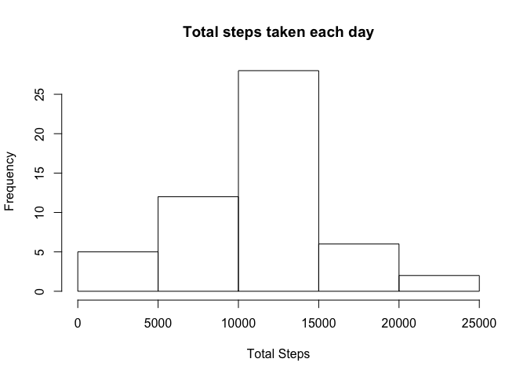

```r
hist(sumDt$steps, xlab="Total Steps", main="Total steps taken each day")
```

##### 3. Mean and Median of the total number of steps taken per day

```r
mean(sumDt$steps)
```

```
## [1] 10766.19
```

```r
median(sumDt$steps)
```

```
## [1] 10765
```

## What is the average daily activity pattern?

```r
avgInt <- rd2 %>% group_by(interval) %>% summarise_each(funs(mean))
```

##### 1. Time series plot of the interval (x-axis) and the average number of steps taken, averaged across all days (y-axis)

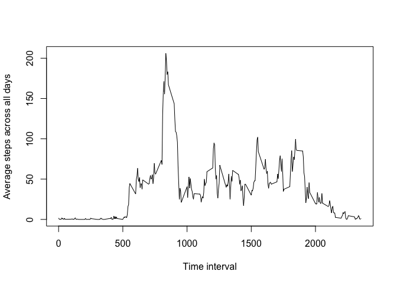

```r
 plot(avgInt$interval, avgInt$steps, type = 'l', xlab="Time interval", ylab="Average steps across all days")
```

##### 2. Which 5-minute interval, on average across all the days in the dataset, contains the maximum number of steps?

Answer: The interval 835, has the maximum number of steps which is 206 (or 206.17).

```r
avgInt[which.max(avgInt$steps), c(1,2)]
```

```
## Source: local data frame [1 x 2]
##
##   interval    steps
## 1      835 206.1698
```